# Data 624 Homework 3

Anthony Pagan

2/22/2020

## Excercise 6.2

The plastics data set consists of the monthly sales (in thousands) of product A for a plastics manufacturer for five years.

### A

Plot the time series of sales of product A. Can you identify seasonal fluctuations and/or a trend-cycle?

The data appears to increase mid year and decrease end of year. Data also looks to have a year to year increase the past 5 years.

```r
glimpse(plastics)
```

```
##  Time-Series [1:60] from 1 to 5.92: 742 697 776 898 1030 ...
```

```r
frequency(plastics)
```

```
## [1] 12
```

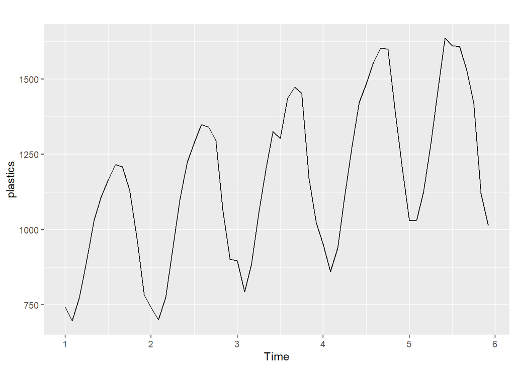

```r
autoplot(plastics, frequency = frequency(plastics))
```

### B

Use a classical multiplicative decomposition to calculate the trend-cycle and seasonal indices.

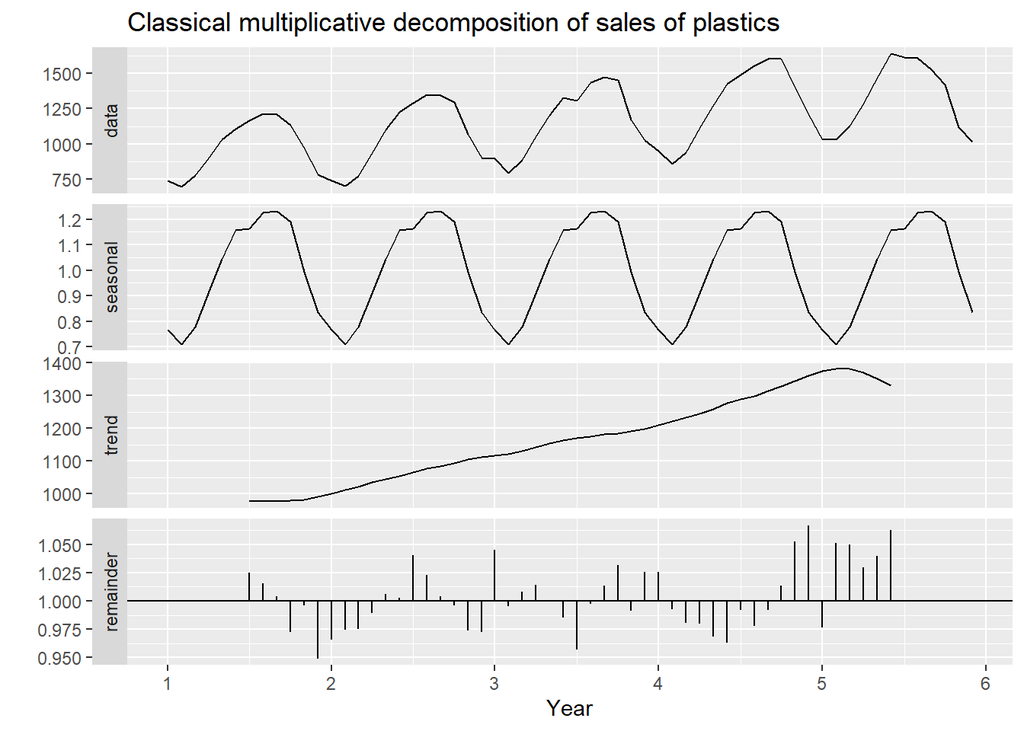

```r
plastics %>% decompose(type="multiplicative")%>%
  autoplot(frequency = frequency(plastics)) + xlab("Year") +
  ggtitle("Classical multiplicative decomposition of sales of plastics")
```

### C

Do the results support the graphical interpretation from part a?

Yes. The overall data plot shows the same upward trend as part A. The seasonal breakdown show that every year there is a similar up and down trend mid year. The trend breakdown confirms that there is anupward trend year to year. The remainder breakdown hint that years 5 and 6 had a bigger impact on the up trendward than the previous 4 years.

### D

Compute and plot the seasonally adjusted data.

```r
library(seasonal)
```

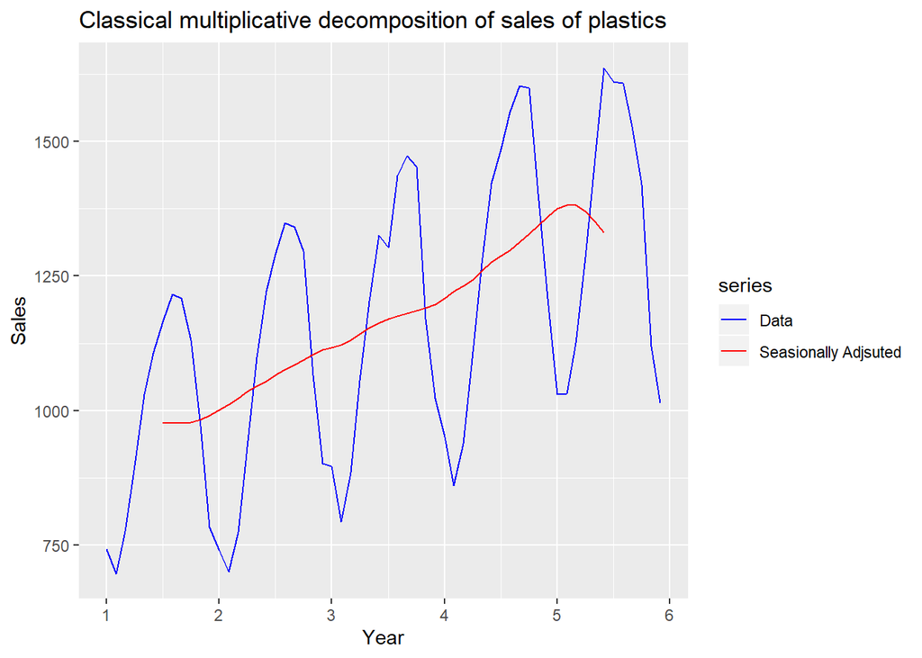

```r
autoplot(plastics, series="Data") +
  autolayer(ma(plastics,12), series="Seasionally Adjsuted") +
  xlab("Year") + ylab("Sales") +
  ggtitle("Classical multiplicative decomposition of sales of plastics") +
  scale_colour_manual(values=c("blue","red"),
                      breaks=c("Data","Seasionally Adjsuted"))
```

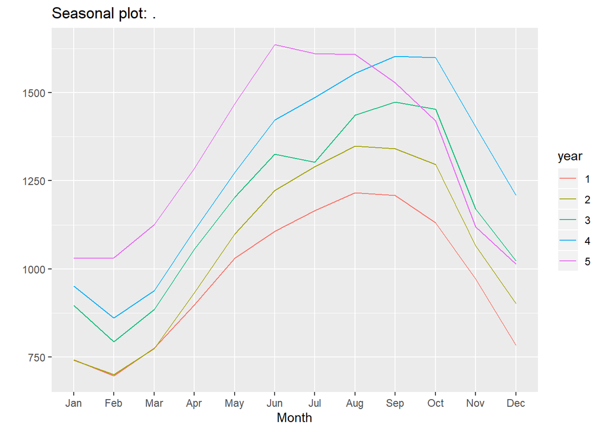

```r
plastics%>% ggseasonplot()
```

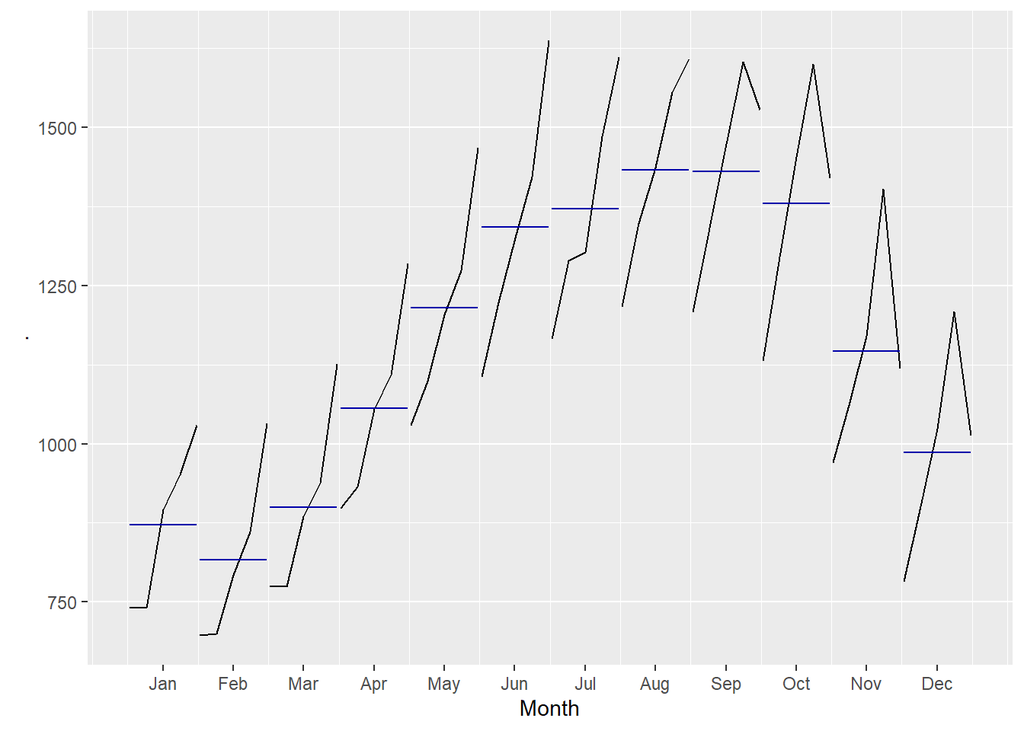

```r
plastics%>% ggsubseriesplot()
```

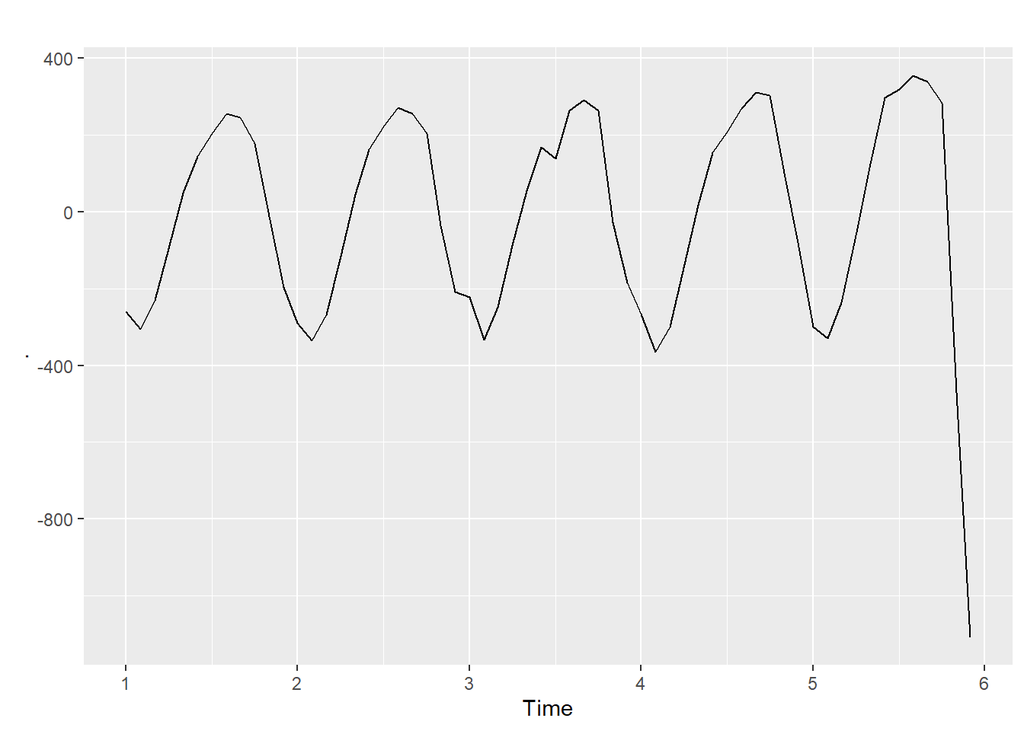

```r
plastics%>% stl(s.window=1, robust=TRUE)%>%seasonal%>%autoplot()
```

### E

Change one observation to be an outlier (e.g., add 500 to one observation), and recompute the seasonally adjusted data. What is the effect of the outlier?

The outier changes the mean/median of the month where the obeservation was modified. There is a drop then an increase between June and July of the 5th year as a result of the new caculations with outlier.

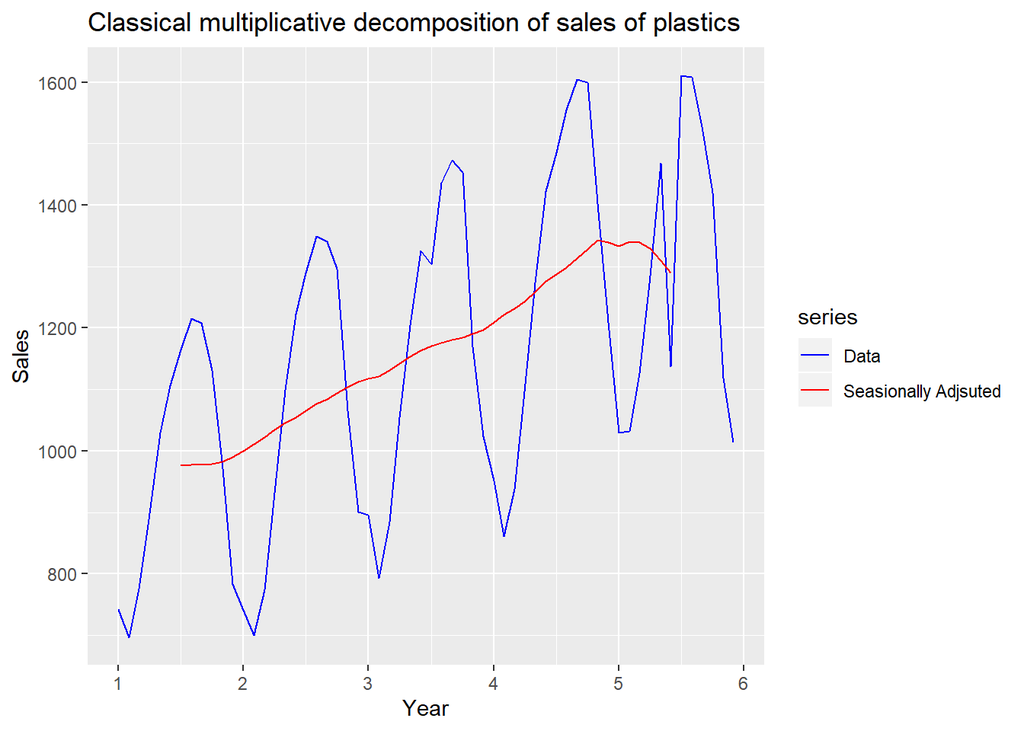

```r
plastics2<-plastics
plastics2[54]<-plastics2[54]-500

autoplot(plastics2, series="Data") +
  autolayer(ma(plastics2,12), series="Seasionally Adjsuted") +
  xlab("Year") + ylab("Sales") +
  ggtitle("Classical multiplicative decomposition of sales of plastics") +
  scale_colour_manual(values=c("blue","red"),
                      breaks=c("Data","Seasionally Adjsuted"))
```

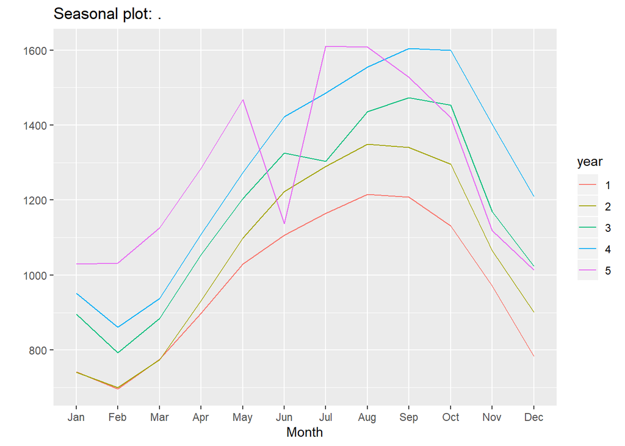

```r
plastics2%>% ggseasonplot()
```

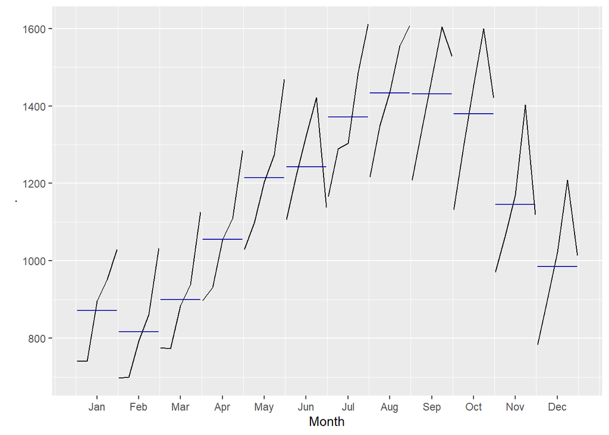

```r
plastics2%>% ggsubseriesplot()
```

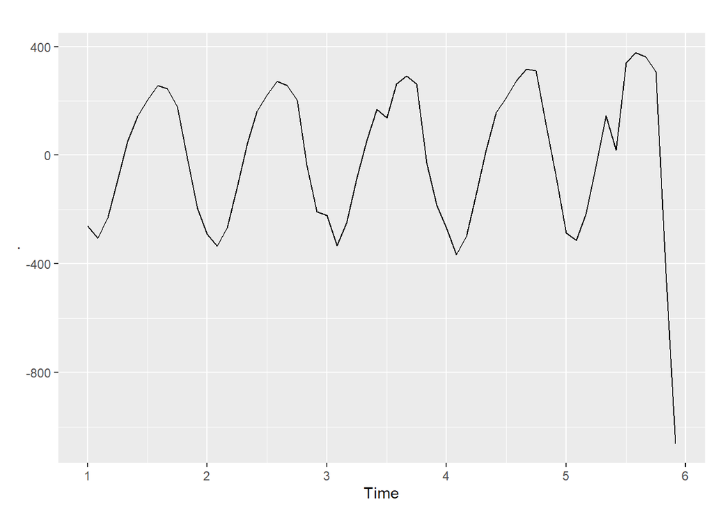

```r
plastics2%>% stl(s.window=1, robust=TRUE)%>%seasonal%>%autoplot()
```

### F

Does it make any difference if the outlier is near the end rather than in the middle of the time series?

In the first outlier update the modificaiton was in the middle of the year. In this update the chanages are being adjusted end of year for December. The plots now show the increases/decreases are toward the end of the year.

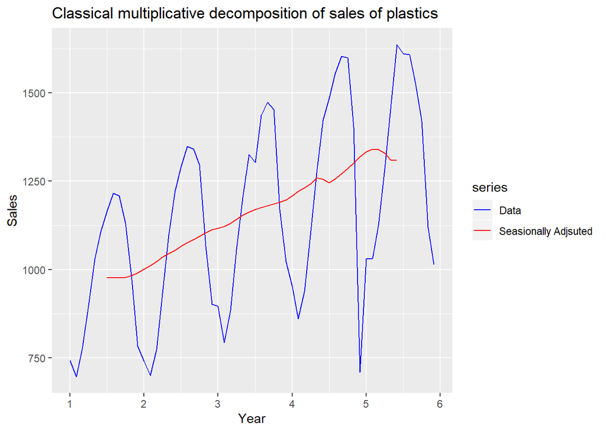

```r
plastics3<-plastics
plastics3[48]<-plastics3[48]-500

autoplot(plastics3, series="Data") +
  autolayer(ma(plastics3,12), series="Seasionally Adjsuted") +
  xlab("Year") + ylab("Sales") +
  ggtitle("Classical multiplicative decomposition of sales of plastics") +
  scale_colour_manual(values=c("blue","red"),
                      breaks=c("Data","Seasionally Adjsuted"))
```

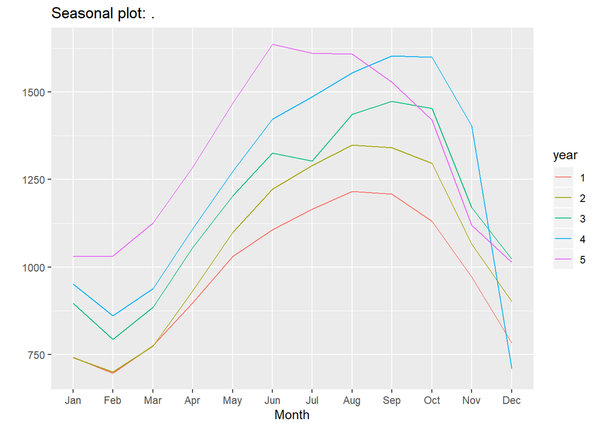

```r
plastics3%>% ggseasonplot()
```

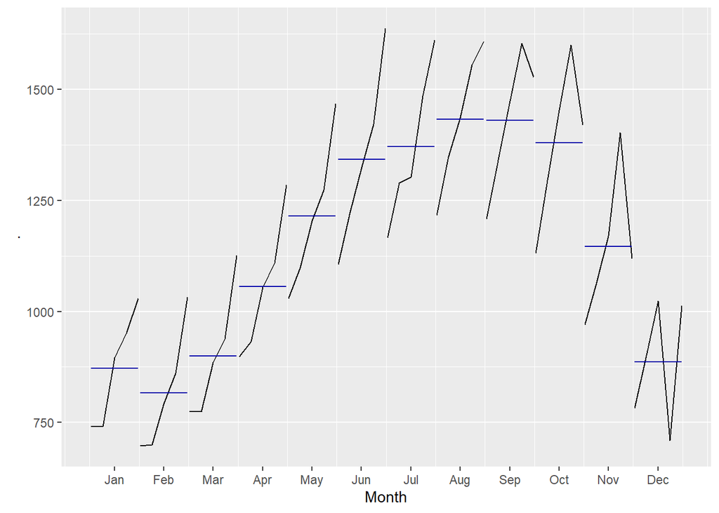

```r
plastics3%>% ggsubseriesplot()
```

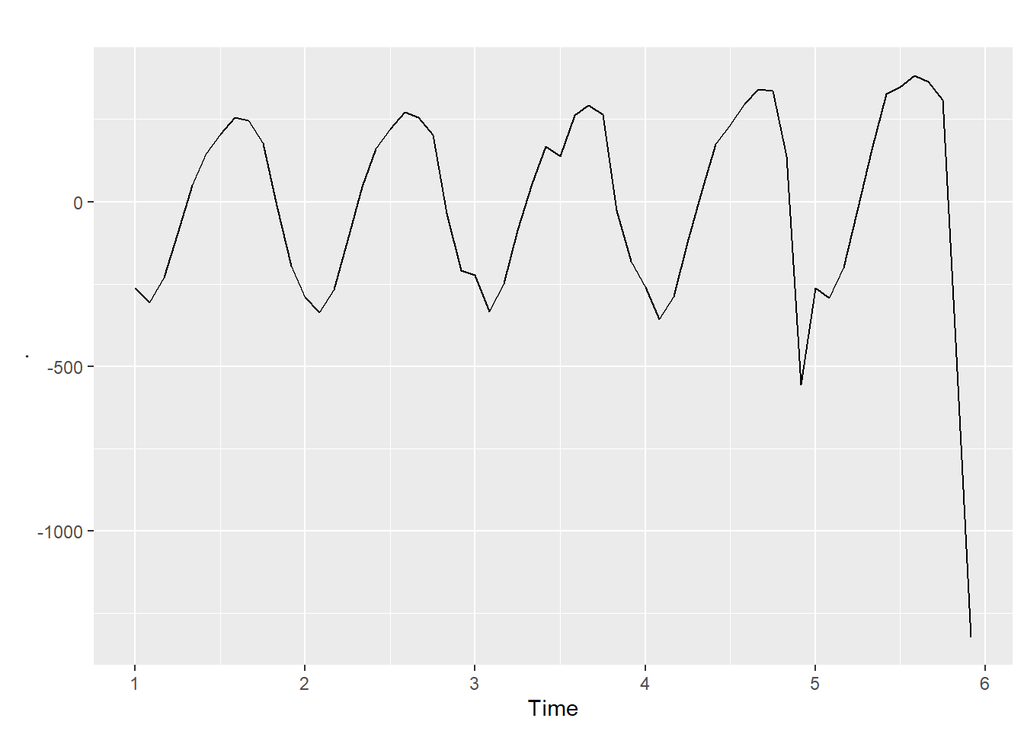

```r
plastics3%>% stl(s.window=1, robust=TRUE)%>%seasonal%>%autoplot()
```

## Excercise 6.3

Recall your retail time series data (from Exercise 3 in Section 2.10). Decompose the series using X11. Does it reveal any outliers, or unusual features that you had not noticed previously?

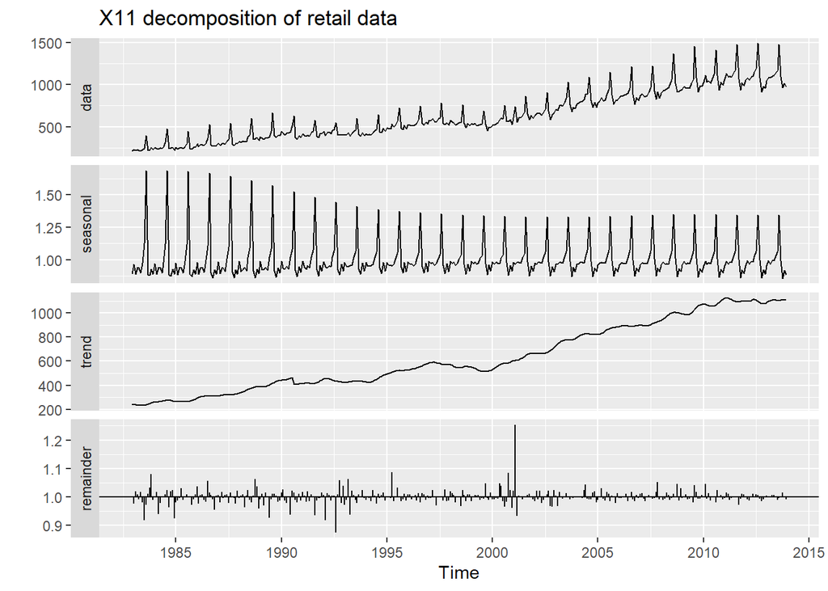

```r
retaildata <- readxl::read_excel("retail.xlsx", skip=1)
retaildata_ts<-ts(retaildata[,"A3349397X"],frequency=12, start=c(1982,12), end=c(2013,12))

retaildata_ts%>% seas(x11="")-> fit
autoplot(fit)+
  ggtitle("X11 decomposition of retail data")
```

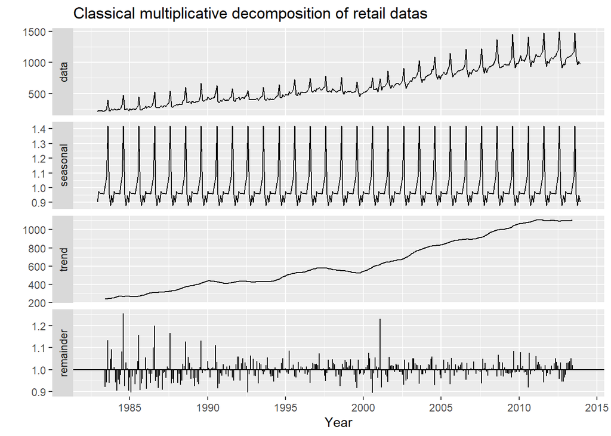

```r
retaildata_ts %>% decompose(type="multiplicative")%>%
  autoplot(frequency = frequency(retaildata)) + xlab("Year") +
  ggtitle("Classical multiplicative decomposition of retail datas")
```